# Analysis of the Top 10 Most Devastating Weather Events in the USA

## Introduction

This report investigates the Top 10 most devasting weather events for mankind based on the type of harm caused (i.e. injury and fatality), as well as damage to property and crops. The analysis data were taken from the U.S. National Oceanic and Atmospheric Administration’s (NOAA) storm database. In this study, NOAA weather data was recorded starting in April 1950 and ending in November 2011.

## Data Processing

The data is stored in a data frame, which needs to be loaded and subsequently manipulated in order to parse out the relevant information for this study. Libraries needed for this study are:

```r
require(data.table)
require(plyr)
require(dplyr)
require(tidyr)
require(ggplot2)
```

The data is stored in a bzip2-compressed comma-separated-value file.

```r
data <- read.csv("repdata-data-StormData.csv.bz2")
```

## Results

The first aspect of this report deals with the effects of severe weather events on people’s health. To this end, health parameters are separated into injuries and fatalities and the Top 10 most devastating events for either category plotted as bar graphs.

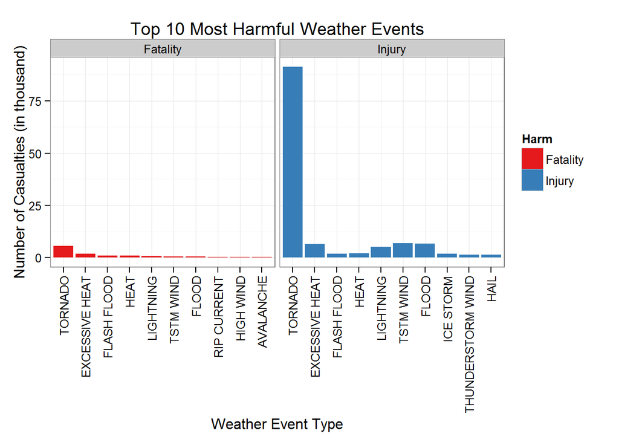

```r
pop_health <- data %>%
  group_by(EVTYPE) %>%
  summarise('Fatality'=sum(FATALITIES, na.rm=T),
            'Injury' = sum(INJURIES, na.rm=T)) %>%
  gather('Harm','number',-EVTYPE) %>%
  group_by(Harm) %>%
  top_n(., 10) %>%
  arrange(desc(number))

pop_health$EVTYPE <- factor(pop_health$EVTYPE, levels=pop_health$EVTYPE)
pop_health <- droplevels(pop_health)

#make two-panel plot
ggplot(pop_health, aes(EVTYPE, number/1000, fill=Harm)) +
  geom_bar(stat='identity') +
  labs(title='Top 10 Most Harmful Weather Events',
       y='Number of Casualties (in thousand)', x='Weather Event Type') +
  facet_grid(. ~ Harm, scales = 'free_x') +
  theme_bw() +
  theme(axis.text.x=element_text(angle=90, hjust=1, vjust=0.5)) +
  scale_fill_manual(values=c("#E41A1C","#377EB8"))
```

The graph shows that tornados caused by far the most fatalities (5633) and injuries (91346) in the United States of America from 1950 until 2011.  
Next, the impact of severe weather on property and crops is evaluted. The NOAA data for this information is stored in columns for crop and property, but a scaling information (stored in two separate columns) also has to be taken into consideration to calculate the amount of damage in $US. In this case, ‘H’ and ‘h’ stand for hundreds, ‘kK’ for thousands, ‘mM’ for millions and ‘bB’ for billions of dollars in damage. Unfortunately, the scaling column also contains other factors, and it is unclear how to evaluate these. For simplicity reasons, the ‘extra’ factors are converted to one. The Top 10 most damaging weather events from the data are parsed out and then printed as bar graphs.

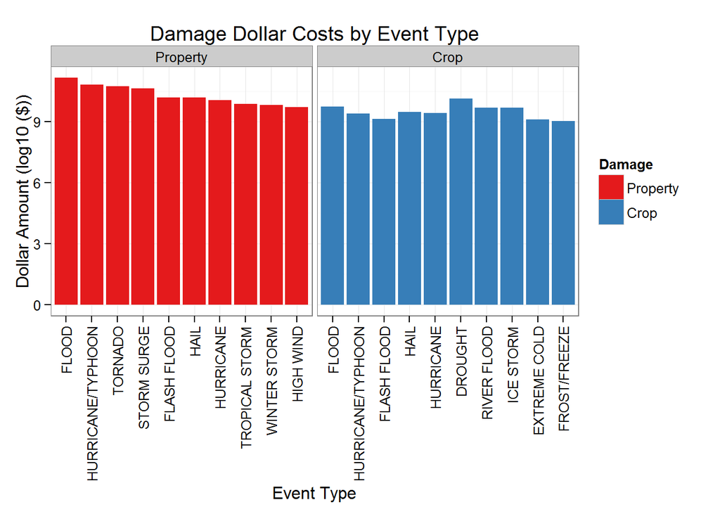

```r
#convert 'h','k', 'm' and 'b' to their respective numeric factor
#and multiply damage variable with said factor
data$CROPDMGEXP <- mapvalues(data$CROPDMGEXP, from=c("b","B","k","K","m","M","0","2","?",""), to=c('1e9','1e9','1e3','1e3','1e6','1e6','1','1','1','1'),
                             warn_missing=F)
data$CROPDMGEXP <- as.numeric(as.character(data$CROPDMGEXP))
data$PROPDMGEXP[!grepl('[hHkKmMbB]', data$PROPDMGEXP)==T] <- 1
data$PROPDMGEXP <- mapvalues(data$PROPDMGEXP, from=c("b","B","k","K","m","M","h","H"), to=c('1e9','1e9','1e3','1e3','1e6','1e6','100','100'),
                             warn_missing=F)
data$PROPDMGEXP <- as.numeric(as.character(data$PROPDMGEXP))

#select crop and property damage, multiply by scaling factor, and create data frame with Top10 most devastating events for crop and propterty damage
damage_data <- data %>%
  mutate('Dollar_Property'= .$PROPDMG * .$PROPDMGEXP,
         'Dollar_Crop'= .$CROPDMG * .$CROPDMGEXP) %>%
  group_by(EVTYPE) %>%
  summarise('Property'=sum(Dollar_Property, na.rm=T),
            'Crop'=sum(Dollar_Crop, na.rm=T)) %>%
  gather('Damage', 'Dollar_Amount', -EVTYPE) %>%
  group_by(Damage) %>%
  top_n(10) %>%
  arrange(desc(Dollar_Amount))

damage_data$EVTYPE <- factor(damage_data$EVTYPE, levels = damage_data$EVTYPE)
damage_data <- droplevels(damage_data)

#make two-panel plot
ggplot(damage_data, aes(EVTYPE, log(Dollar_Amount, 10), fill=Damage)) +
  facet_grid(. ~ Damage, scales='free_x') +
  geom_bar(stat='identity', position='dodge', width=0.9) +
  theme_bw() +
  labs(title='Damage Dollar Costs by Event Type', x='Event Type', y='Dollar Amount (log10 ($))') +
  theme(axis.text.x=element_text(angle=90, hjust=1, vjust=0.5)) +
  scale_fill_manual(values=c("#E41A1C","#377EB8"))
```